# Thermal physics homework #1

1. Simple probability stuff

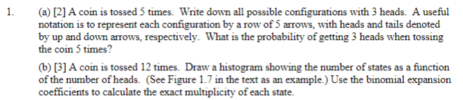

1a)  
u = heads, d = tails

uuudd, uudud, uuddu, uduud, ududu, udduu, duuud, duudu, duduu, dduu (10 different ways)

To double check my result, I'll check the multiplicity $g(N,n) = \dfrac{N!}{n!(N-n)!} $ $$g(5,3) = \dfrac{5!}{3!(2)!} = 10 $$

```python
import math

g = math.factorial(5) / (math.factorial(3) * 2)
g
```

```
10.0
```

1b)

MS paint drawing? Actually why not have my snake friend draw it

[figure not shown]

```python
import matplotlib.pyplot as plt

heads = []
for i in range(13):
    multiplicity = math.factorial(12) / (math.factorial(i)*math.factorial(12-i))
    heads.append(multiplicity)

plt.bar(range(len(heads)),heads)
plt.title('Arangements of 12 coin flips')
plt.xlabel('# of heads')
plt.ylabel('count')
plt.show()
```

2. As you can guess, I think I'd rather work with python

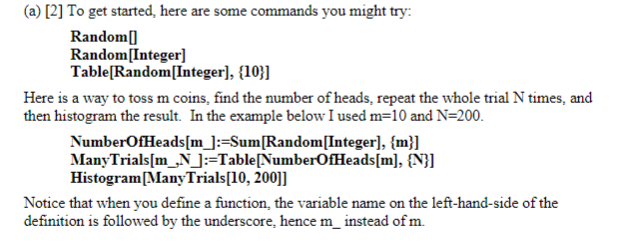

2a)  
I think I can do these in python

```python
import numpy as np

np.random.random()
np.random.randint(0,2)

coin_flips = []
for i in range(10):
    coin_flips.append(np.random.randint(0,2))

numheads = sum(coin_flips)

#I've already got our histogram above, just need to use plt.hist() instead
```

2b)

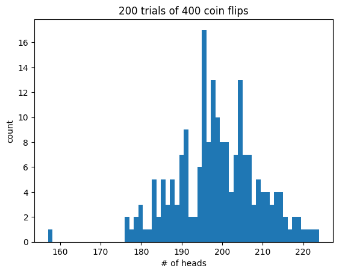

```python
trials = 200
trial_size = 400
bins = 60

histvals = []

for i in range(trials):
    coin_flips = []
    for j in range(trial_size):
        coin_flips.append(np.random.randint(0,2))
    histvals.append(sum(coin_flips))

plt.hist(histvals,bins)
plt.title(f'{trials} trials of {trial_size} coin flips')
plt.xlabel('# of heads')
plt.ylabel('count')
plt.show()
```

2c)  
just copy paste the above. I'll also throw 2d into here

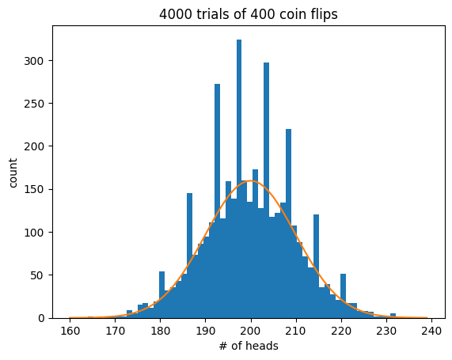

```python
trials = 4000
trial_size = 400
bins = 60

histvals = []

for i in range(trials):
    coin_flips = []
    for j in range(trial_size):
        coin_flips.append(np.random.randint(0,2))
    histvals.append(sum(coin_flips))

plt.hist(histvals,bins)
plt.title(f'{trials} trials of {trial_size} coin flips')
plt.xlabel('# of heads')
plt.ylabel('count')
#plt.show()

#print('not sure why we get these peaks but they\'re different with each run')

x = np.arange(160,240,1)
y = 4000*np.sqrt(2/(400*np.pi))*np.exp(-2*(x-200)**2/400)

plt.plot(x,y)
plt.show()
```

2e)  
lets find $\delta n$

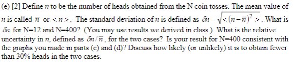

$\sqrt{Npq} = \sqrt{N*.25}$

$N = 12,$ $\delta n = 1.732$, $\dfrac{1.732}{6} = 0.289 $  
$N = 400,$ $\delta n = 10$, $\dfrac{10}{200} = 0.050$

```python
np.sqrt(400*.25)
1.732/6
```

```
0.2886666666666667
```

3a)  
considering gas

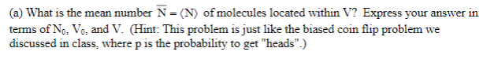

$V\leq V_0$

There is a $\dfrac{V}{V_0}$ chance that a single particle is in V, so the mean number is that value multiplied by the total number of particles $\bar N = N_0 \dfrac{V}{V_0}$

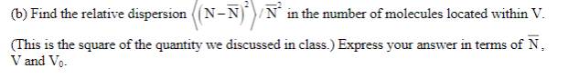

b)  
$<(N-\bar N)^2>$ is variance $(\delta N)^2=Npq$.

$q$ is the probability a particle isn't in $V$, $q = \dfrac{V_0-V}{V_0}=1-\dfrac{V}{V_0} $

Substituting in these values we find relative dispersion is $\dfrac{(N_0(\frac{V}{V_0})(1-\frac{V}{V_0}))}{N_0\frac{V}{V_0}}$

In terms of $\bar N, V, \text{ and } V_0$, this is $$\dfrac{<(N-\bar N)^2>}{\bar N ^2} = \dfrac{(\bar N (1-\frac{V}{V_0}))}{\bar N}$$

c) This approaches $\dfrac{\bar N}{\bar N} = 1$

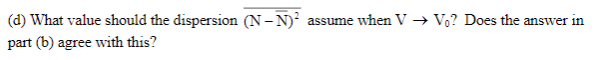

d) This approaches $\dfrac{\bar N (1-1)}{\bar N} = 0$, which makes sense since no gas molecules can be outside the volume

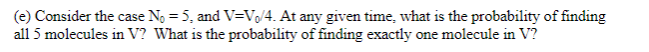

This is a binomial with p = 1/4 and N=5, a biased coin flip. The probabilibty of finding all five inside is

$$p^N=\dfrac{1}{4^5}=.000976$$

And the probability of only finding one inside is

$$pq^4 = \dfrac{1}{4}(\dfrac{3}{4})^4= .0791$$

Yay all done